# A quick introduction to FLR

14 February, 2017

The Fisheries Library in R (FLR) is a collection of tools for quantitative fisheries science, developed in the R language, that facilitates the construction of bio-economic simulation models of fisheries systems.

FLR builds on the powerful R environment and syntax to create a [domain-specific language](https://en.wikipedia.org/wiki/Domain-specific_language) for the quantitative analysis of the expected risks and effects of fisheries management decisions. The classes and methods in FLR consider uncertainty an integral part of our knowledge of fisheries system. […]

## Required packages

To follow this tutorial you should have installed the following packages:

- FLR: [FLCore](http://www.flr-project.org/FLCore/)

You can do so as follows,

```r
install.packages(c("FLCore"), repos="http://flr-project.org/R")
```

# Getting started with FLCore classes

The main *classes* (i.e. data structures) and methods (i.e. procedures) in the FLR system are found in the `FLCore` package. Let’s load it first

```r
library(FLCore)
```

so can then inspect an example object

```r
data(ple4)
```

The `ple4` object is of class `FLStock`, used in **FLR** to represent the representation of the fish population that is constructed from catch and abundance data through an stock assesssment. `FLStock` is an S4 class (see `?Classes_Details` for futher details on S4 classes), consisting of a number of slots able to hold data or results for each of the elements in it. By calling the `summary` method on the object

```r
summary(ple4)
```

```
## An object of class "FLStock"
##
## Name: Plaice in IV
## Description: Imported from a VPA file. ( N:\Projecten\ICES WG\Demersale werkgroep  [...]
## Quant: age
## Dims:  age   year    unit    season  area    iter
##  10  52  1   1   1   1
##
## Range:  min  max pgroup  minyear maxyear minfbar maxfbar
##  1   10  10  1957    2008    2   6
##
## catch         : [ 1 52 1 1 1 1 ], units =  t
## catch.n       : [ 10 52 1 1 1 1 ], units =  10^3
## catch.wt      : [ 10 52 1 1 1 1 ], units =  kg
## discards      : [ 1 52 1 1 1 1 ], units =  t
## discards.n    : [ 10 52 1 1 1 1 ], units =  10^3
## discards.wt   : [ 10 52 1 1 1 1 ], units =  kg
## landings      : [ 1 52 1 1 1 1 ], units =  t
## landings.n    : [ 10 52 1 1 1 1 ], units =  10^3
## landings.wt   : [ 10 52 1 1 1 1 ], units =  kg
## stock         : [ 1 52 1 1 1 1 ], units =  t
## stock.n       : [ 10 52 1 1 1 1 ], units =  10^3
## stock.wt      : [ 10 52 1 1 1 1 ], units =  kg
## m             : [ 10 52 1 1 1 1 ], units =  m
## mat           : [ 10 52 1 1 1 1 ], units =  NA
## harvest       : [ 10 52 1 1 1 1 ], units =  f
## harvest.spwn  : [ 10 52 1 1 1 1 ], units =  NA
## m.spwn        : [ 10 52 1 1 1 1 ], units =  NA
```

we can inspect the slots, dimensions and structure. Most slots in the class (e.g. `catch` or `stock.n`) of themselves of another **FLCore** class, `FLQuant`. This class, the basic element used to assemble all other classes in **FLR**, is an 6-dimensional array that can take advantange of the powerful array algebra capabilities of R. All slots can be accessed and modified using accessors and replacement methods

```r
catch(ple4)
```

```
## An object of class "FLQuant"
## , , unit = unique, season = all, area = unique
##
##      year
## age   1957   1958   1959   1960   1961   1962   1963   1964   1965
##   all  78423  88240 109238 117138 118331 125272 148170 147357 139820
##      year
## age   1966   1967   1968   1969   1970   1971   1972   1973   1974
##   all 166784 163178 139503 142896 160026 136932 142495 143883 157804
##      year
## age   1975   1976   1977   1978   1979   1980   1981   1982   1983
##   all 195154 167089 176691 159727 213422 171235 172671 204286 218424
##      year
## age   1984   1985   1986   1987   1988   1989   1990   1991   1992
##   all 226930 220928 296876 342985 311635 277738 228734 229607 183284
##      year
## age   1993   1994   1995   1996   1997   1998   1999   2000   2001
##   all 152242 134392 120316 133797 179957 175002 151708 126142 182578
##      year
## age   2002   2003   2004   2005   2006   2007   2008
##   all 125884 145390 117702 111060 121205  90283  96040
##
## units:  t
```

```r
m(ple4) <- m(ple4) + m(ple4) * 0.5
```

Other standard R methods have also been defined for these classes in a way that is as intuitive as possible for any R user. For example, subsetting using the `[` operator works on both `FLStock`

```r
summary(ple4[, 1:10])
```

```
## An object of class "FLStock"
##
## Name: Plaice in IV
## Description: Imported from a VPA file. ( N:\Projecten\ICES WG\Demersale werkgroep  [...]
## Quant: age
## Dims:  age   year    unit    season  area    iter
##  10  10  1   1   1   1
##
## Range:  min  max pgroup  minyear maxyear minfbar maxfbar
##  1   10  10  1957    1966    2   6
##
## catch         : [ 1 10 1 1 1 1 ], units =  t
## catch.n       : [ 10 10 1 1 1 1 ], units =  10^3
## catch.wt      : [ 10 10 1 1 1 1 ], units =  kg
## discards      : [ 1 10 1 1 1 1 ], units =  t
## discards.n    : [ 10 10 1 1 1 1 ], units =  10^3
## discards.wt   : [ 10 10 1 1 1 1 ], units =  kg
## landings      : [ 1 10 1 1 1 1 ], units =  t
## landings.n    : [ 10 10 1 1 1 1 ], units =  10^3
## landings.wt   : [ 10 10 1 1 1 1 ], units =  kg
## stock         : [ 1 10 1 1 1 1 ], units =  t
## stock.n       : [ 10 10 1 1 1 1 ], units =  10^3
## stock.wt      : [ 10 10 1 1 1 1 ], units =  kg
## m             : [ 10 10 1 1 1 1 ], units =  m
## mat           : [ 10 10 1 1 1 1 ], units =  NA
## harvest       : [ 10 10 1 1 1 1 ], units =  f
## harvest.spwn  : [ 10 10 1 1 1 1 ], units =  NA
## m.spwn        : [ 10 10 1 1 1 1 ], units =  NA
```

and `FLQuant`

```r
stock.n(ple4)[1,]
```

```
## An object of class "FLQuant"
## , , unit = unique, season = all, area = unique
##
##    year
## age 1957    1958    1959    1960    1961    1962    1963    1964
##   1  457973  698110  863386  757299  860577  589154  688367 2231504
##    year
## age 1965    1966    1967    1968    1969    1970    1971    1972
##   1  694575  586779  401298  434281  648877  650584  410281  366633
##    year
## age 1973    1974    1975    1976    1977    1978    1979    1980
##   1 1312097 1132831  864875  692849  988889  913474  891160 1128822
##    year
## age 1981    1982    1983    1984    1985    1986    1987    1988
##   1  869640 2029493 1306601 1261067 1849179 4732214 1918256 1770637
##    year
## age 1989    1990    1991    1992    1993    1994    1995    1996
##   1 1184055 1033216  910370  773003  522410  434986 1153325 1283485
##    year
## age 1997    1998    1999    2000    2001    2002    2003    2004
##   1 2105676  765785  836929  927442  516739 1612473  505292 1159019
##    year
## age 2005    2006    2007    2008
##   1  714344  820006  949341  844041
##
## units:  10^3
```

while ensuring that the result are always valid object of the same class. For example, selecting a single element along the first dimension (`age`) did not drop that dimension from the object, in contrast with the standard behaviour in R for `array`.

Similarly to the `summary` method above, a common set of methods exist for each class to create new objects,

```r
FLQuant(rlnorm(30), dimnames=list(age=0:5, year=2012:2017))
```

```
## An object of class "FLQuant"
## , , unit = unique, season = all, area = unique
##
##    year
## age 2012    2013    2014    2015    2016    2017
##   0 0.60352 1.51710 1.68515 0.59522 0.15654 0.60352
##   1 1.93833 6.16351 0.84972 1.43151 4.84358 1.93833
##   2 0.24826 0.99065 0.61229 5.05653 3.67105 0.24826
##   3 3.14748 3.13919 0.93561 0.69980 0.88436 3.14748
##   4 0.97440 5.28007 1.36443 1.19544 0.69089 0.97440
##   5 2.09946 1.06234 0.53418 0.81529 2.49983 2.09946
##
## units:  NA
```

coerce to and from other classes,

```r
head(as.data.frame(ple4))
```

```
##    slot age year   unit season   area iter   data
## 1 catch all 1957 unique    all unique    1  78423
## 2 catch all 1958 unique    all unique    1  88240
## 3 catch all 1959 unique    all unique    1 109238
## 4 catch all 1960 unique    all unique    1 117138
## 5 catch all 1961 unique    all unique    1 118331
## 6 catch all 1962 unique    all unique    1 125272
```

or plot an object

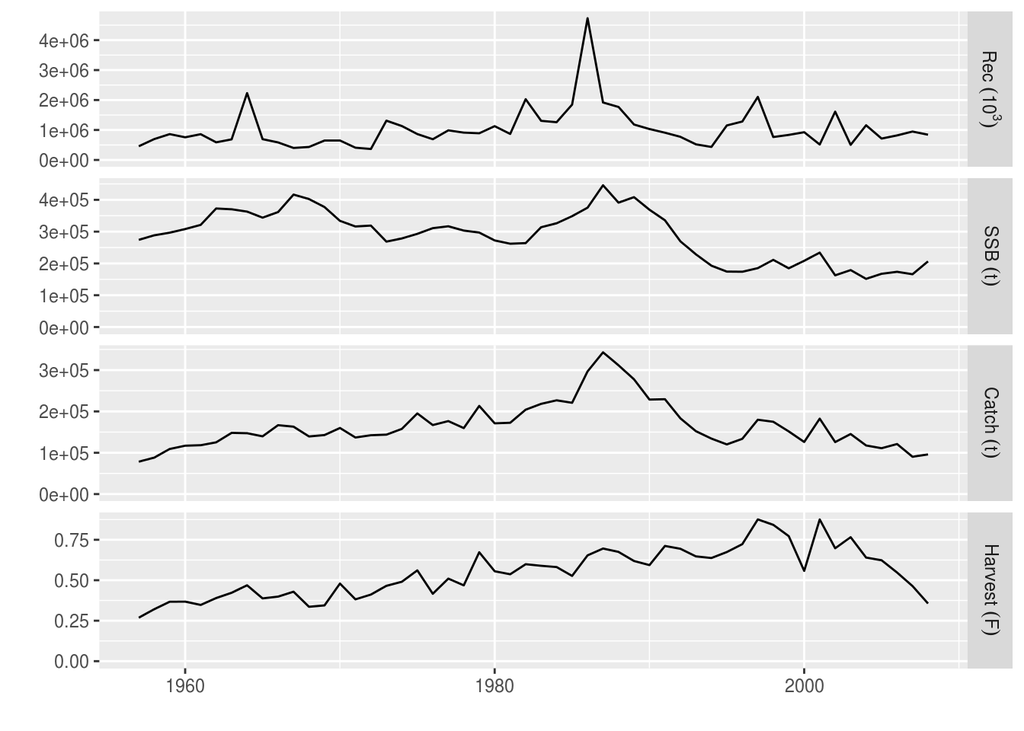

FLStock plot for ple4

```r
plot(ple4)
```

A number of fisheries specific calculations are also available, Figure 1. For example, the estimated spawning stock biomass (SSB), can be obtained from an `FLStock` object using

```r
ssb(ple4)
```

```
## An object of class "FLQuant"
## , , unit = unique, season = all, area = unique
##
##      year
## age   1957   1958   1959   1960   1961   1962   1963   1964   1965
##   all 274205 288540 296825 308164 321354 372863 370373 363077 344013
##      year
## age   1966   1967   1968   1969   1970   1971   1972   1973   1974
##   all 361549 416563 402521 377432 333933 316343 319062 268714 278648
##      year
## age   1975   1976   1977   1978   1979   1980   1981   1982   1983
##   all 293136 310954 316929 303433 297122 272416 262061 263998 314021
##      year
## age   1984   1985   1986   1987   1988   1989   1990   1991   1992
##   all 326341 348675 375392 445855 391254 408489 368969 335747 269528
##      year
## age   1993   1994   1995   1996   1997   1998   1999   2000   2001
##   all 228668 193093 174408 173903 185308 211327 184733 208393 234078
##      year
## age   2002   2003   2004   2005   2006   2007   2008
##   all 162725 179158 151508 167531 173783 166061 206480
##
## units:  t
```

or the mean fishing mortality accross the fully-selected ages ($\bar{F}$) with

```r
fbar(ple4)
```

```
## An object of class "FLQuant"
## , , unit = unique, season = all, area = unique
##
##      year
## age   1957    1958    1959    1960    1961    1962    1963    1964
##   all 0.26857 0.32106 0.36734 0.36796 0.34756 0.39012 0.42276 0.46878
##      year
## age   1965    1966    1967    1968    1969    1970    1971    1972
##   all 0.38796 0.39896 0.42923 0.33621 0.34457 0.47965 0.38206 0.41158
##      year
## age   1973    1974    1975    1976    1977    1978    1979    1980
##   all 0.46551 0.49072 0.56113 0.41641 0.51007 0.46862 0.67312 0.55555
##      year
## age   1981    1982    1983    1984    1985    1986    1987    1988
##   all 0.53705 0.59912 0.58934 0.58159 0.52695 0.65386 0.69596 0.67530
##      year
## age   1989    1990    1991    1992    1993    1994    1995    1996
##   all 0.61895 0.59361 0.71195 0.69443 0.64752 0.63741 0.67444 0.72301
##      year
## age   1997    1998    1999    2000    2001    2002    2003    2004
##   all 0.87588 0.84233 0.77264 0.55795 0.87567 0.69763 0.76597 0.64015
##      year
## age   2005    2006    2007    2008
##   all 0.62343 0.54764 0.46392 0.35631
##
## units:  f
```

## Class validity

Object validity is checked by the class constructor but also by the replacement methods, for example when calling

```r
catch(ple4) <- landings(ple4) + discards(ple4)
```

# A modelling example: the FLSR class

A different type of class defined in **FLCore** is `FLSR`. This class allows for fitting, exploration and prediction of a stock-recruitment relationship. An example dataset is also available, corresponding to the North Sea herring stock

```r
data(nsher)
summary(nsher)
```

```
## An object of class "FLSR"
##
## Name:
## Description:
## Quant: age
## Dims:  age   year    unit    season  area    iter
##  1   45  1   1   1   1
##
## Range:  min  minyear max maxyear
##  0   1960    0   2004
##
## rec           : [ 1 45 1 1 1 1 ], units =  10^3
## ssb           : [ 1 45 1 1 1 1 ], units =  t*10^3
## residuals     : [ 1 45 1 1 1 1 ], units =  NA
## fitted        : [ 1 45 1 1 1 1 ], units =  10^3
##
## Model:   rec ~ a * ssb * exp(-b * ssb)
## <environment: 0x10bd9f48>
## Parameters:
##     params
## iter     a        b
##    1 119.4 0.009451
##
## Log-likelihood:  15.862(0)
## Variance-covariance:
##             a         b
##   a 255.33882 1.809e-02
##   b   0.01809 1.993e-06
```

The class holds together `FLQuant` slots for inputs (`rec` for recruitment in numbers and `ssb` for spawning stock biomass or any other proxy of stock reproductive potential) and outputs of the fit (`fitted` for the estimated recruitment, and `residuals`, the log residuals of the estimates). It also contains the necessary elements for the model fit to be carried out using maximum likelihood estimation:

- `logl`: a function that computes the log-likehood to be passed on to `optim`.
- `model`: a formula to calculate the estimated recruitment.
- `initial`: a function to obtain initial parameter values for the minimization algorithm.

By calling the method that carries out the minimization, `fmle`, we obtain a new object in which the results of the fit are now available

- `params`: the estimated parameters
- `logLik`: the log-likelihood and degrees of freedom
- `covar`: the variance-covariance matrix of the fit
- `hessian`: the Hessian matrix of the fit

as well as some other information returned by the fitting procedure.

Of course we can visualize the result of the model fit, together with an useful set of diagnostics, by simply calling

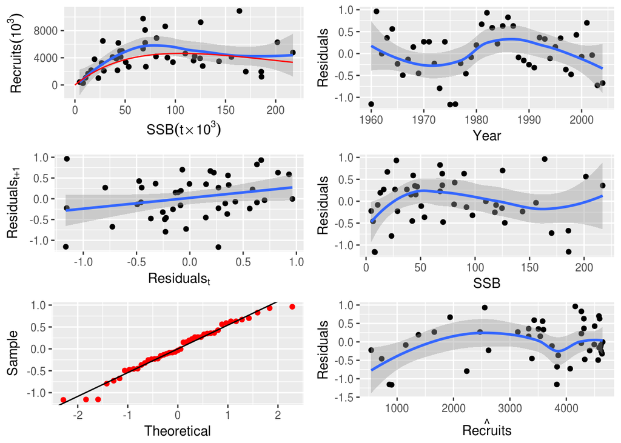

```r
plot(nsher)
```

# References

L. T. Kell, I. Mosqueira, P. Grosjean, J-M. Fromentin, D. Garcia, R. Hillary, E. Jardim, S. Mardle, M. A. Pastoors, J. J. Poos, F. Scott, R. D. Scott; FLR: an open-source framework for the evaluation and development of management strategies. *ICES J Mar Sci* 2007; 64 (4): 640-646. doi: 10.1093/icesjms/fsm012

# More information

- You can submit bug reports, questions or suggestions on this tutorial at https://github.com/flr/doc/issues.
- Or send a pull request to https://github.com/flr/doc/
- For more information on the FLR Project for Quantitative Fisheries Science in R, visit the FLR webpage, http://flr-project.org.

## Software Versions

- R version 3.3.2 (2016-10-31)
- FLCore: 2.6.0.20170130
- **Compiled**: Tue Feb 14 16:48:19 2017

## License

This document is licensed under the [Creative Commons Attribution-ShareAlike 4.0 International](https://creativecommons.org/licenses/by-sa/4.0) license.

## Author information

**Iago MOSQUEIRA**. European Commission Joint Research Centre (JRC), Institute for the Protection and Security of the Citizen (IPSC), Maritime Affairs Unit, Via E. Fermi 2749, 21027 Ispra VA, Italy. https://ec.europa.eu/jrc/